# R Notebook

Homework

```r
library(janitor)
```

| customer_id | gender | age | annual_income_k | spending_score_1_100 |
| --- | --- | --- | --- | --- |
| 1 | Male | 19 | 15 | 39 |
| 2 | Male | 21 | 15 | 81 |
| 3 | Female | 20 | 16 | 6 |
| 4 | Female | 23 | 16 | 77 |
| 5 | Female | 31 | 17 | 40 |
| 6 | Female | 22 | 17 | 76 |
| 7 | Female | 35 | 18 | 6 |
| 8 | Female | 23 | 18 | 94 |
| 9 | Male | 64 | 19 | 3 |
| 10 | Female | 30 | 19 | 72 |

[output cut: 190 more lines]

Marketing : spending_score and annual_income

| spending_score_1_100 | annual_income_k |
| --- | --- |
| 39 | 15 |
| 81 | 15 |
| 6 | 16 |
| 77 | 16 |
| 40 | 17 |
| 76 | 17 |
| 6 | 18 |
| 94 | 18 |
| 3 | 19 |
| 72 | 19 |

[output cut: 190 more lines]

# Starting Point

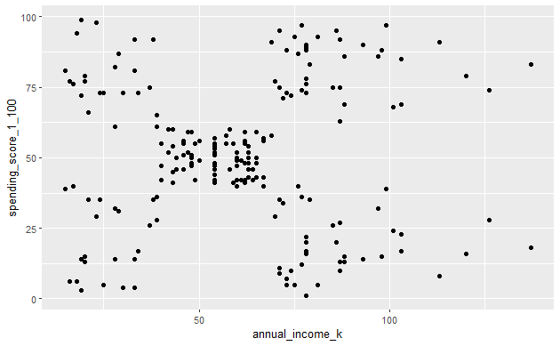

From the graph the first impression is that there are 5 groups. There is a small group of customers with low income but high spending_score;there is another with low -medium income and low-medium spending_score. The third group and, perhaps the most interesting,there is a group of customers with medium income ( around 50 k per year) and medium spending_score and very concentrate from the others 4 groups. The last two groups are these customers with high income, one with also a high spending_score and another low spending income. These last three groups could be the targeting.

Scale the data

| spending_score_1_100 | annual_income_k |
| --- | --- |
| -0.433713114 | -1.73464625 |
| 1.192711064 | -1.73464625 |
| -1.711617825 | -1.69657236 |
| 1.037813523 | -1.69657236 |
| -0.394988729 | -1.65849848 |
| 0.999089138 | -1.65849848 |
| -1.711617825 | -1.62042459 |
| 1.696128071 | -1.62042459 |
| -1.827790981 | -1.58235070 |
| 0.844191597 | -1.58235070 |

[output cut: 190 more lines]

Making a cluster

```r
marketing_cluster5
```

```
K-means clustering with 5 clusters of sizes 22, 39, 23, 35, 81

Cluster means:
  spending_score_1_100 annual_income_k
1           1.12934389      -1.3262173
2           1.23640011       0.9891010
3          -1.13411939      -1.3042458
4          -1.28122394       1.0523622
5          -0.02638995      -0.2004097

Clustering vector:
  [1] 3 1 3 1 3 1 3 1 3 1 3 1 3 1 3 1 3 1 3 1 3 1 3 1 3 1 3 1 3 1 3 1 3 1 3 1 3 1 3 1 3 1 3 5 3 1 5
 [48] 5 5 5 5 5 5 5 5 5 5 5 5 5 5 5 5 5 5 5 5 5 5 5 5 5 5 5 5 5 5 5 5 5 5 5 5 5 5 5 5 5 5 5 5 5 5 5
 [95] 5 5 5 5 5 5 5 5 5 5 5 5 5 5 5 5 5 5 5 5 5 5 5 5 5 5 5 5 5 2 4 2 5 2 4 2 4 2 5 2 4 2 4 2 4 2 4
[142] 2 5 2 4 2 4 2 4 2 4 2 4 2 4 2 4 2 4 2 4 2 4 2 4 2 4 2 4 2 4 2 4 2 4 2 4 2 4 2 4 2 4 2 4 2 4 2
[189] 4 2 4 2 4 2 4 2 4 2 4 2

Within cluster sum of squares by cluster:
[1]  5.217630 19.655252  7.577407 18.304646 14.485632
 (between_SS / total_SS =  83.6 %)

Available components:

[1] "cluster"      "centers"      "totss"        "withinss"     "tot.withinss" "betweenss"
[7] "size"         "iter"         "ifault"
```

```r
library(broom)
```

| spending_score_1_100 | annual_income_k | size | withinss | cluster |
| --- | --- | --- | --- | --- |
| 1.12934389 | -1.3262173 | 22 | 5.217630 | 1 |
| 1.23640011 | 0.9891010 | 39 | 19.655252 | 2 |
| -1.13411939 | -1.3042458 | 23 | 7.577407 | 3 |
| -1.28122394 | 1.0523622 | 35 | 18.304646 | 4 |
| -0.02638995 | -0.2004097 | 81 | 14.485632 | 5 |

| spending_score_1_100 | annual_income_k | .cluster |
| --- | --- | --- |
| -0.433713114 | -1.73464625 | 3 |
| 1.192711064 | -1.73464625 | 1 |
| -1.711617825 | -1.69657236 | 3 |
| 1.037813523 | -1.69657236 | 1 |
| -0.394988729 | -1.65849848 | 3 |
| 0.999089138 | -1.65849848 | 1 |
| -1.711617825 | -1.62042459 | 3 |
| 1.696128071 | -1.62042459 | 1 |
| -1.827790981 | -1.58235070 | 3 |
| 0.844191597 | -1.58235070 | 1 |

[output cut: 190 more lines]

| totss | tot.withinss | betweenss | iter |
| --- | --- | --- | --- |
| 398 | 65.24057 | 332.7594 | 2 |

k value marketing5

| k | kclust | tidied | glanced | augmented |
| --- | --- | --- | --- | --- |
| 1 |  |  |  |  |
| 2 |  |  |  |  |
| 3 |  |  |  |  |
| 4 |  |  |  |  |
| 5 |  |  |  |  |
| 6 |  |  |  |  |
| 7 |  |  |  |  |
| 8 |  |  |  |  |
| 9 |  |  |  |  |
| 10 |  |  |  |  |

[output cut: 30 more lines]

```r
library(factoextra)
```

Personally, I feel the silhouette coefficient method is the most visible, I run two methods : Silhouette and Elbow

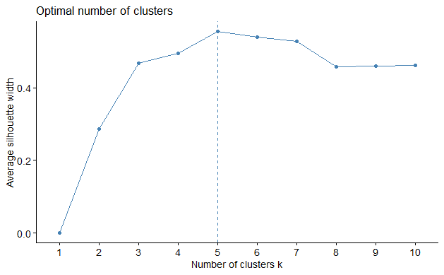

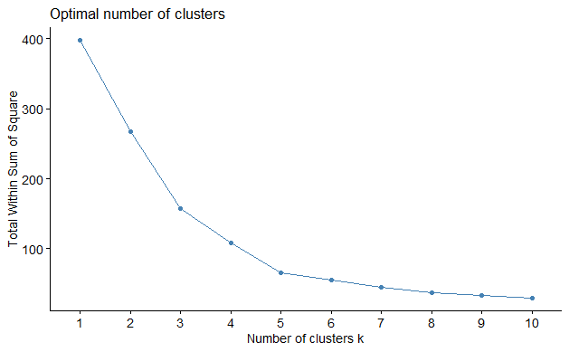

```
Clustering k = 1,2,..., K.max (= 10): .. done
Bootstrapping, b = 1,2,..., B (= 100)  [one "." per sample]:
.................................................. 50
.................................................. 100
```

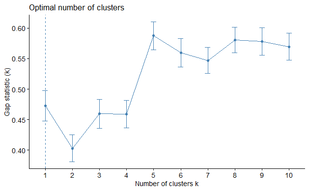

```r
fviz_nbclust(marketing_scaled,
             kmeans,
             method = 'gap',
             nstart = 25)
```

According with the GAP Statistic method, the optimal cluster is 1!.

#Run few plots with different k values 5,3.

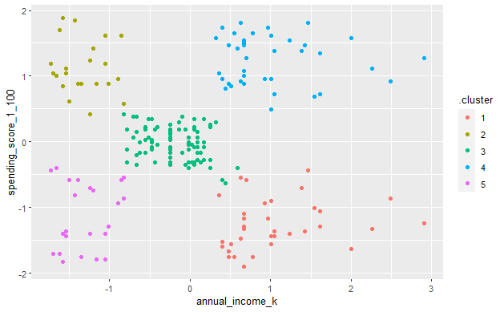

This plot is like a repetition of the first plot with colours

| .cluster | mean(annual_income_k) | mean(spending_score_1_100) |
| --- | --- | --- |
| 1 | 1.0523622 | -1.28122394 |
| 2 | -1.3262173 | 1.12934389 |
| 3 | -0.2004097 | -0.02638995 |
| 4 | 0.9891010 | 1.23640011 |
| 5 | -1.3042458 | -1.13411939 |

The visualization and the average score marks that there is a group with positive annual income but negative spending_score, that could be the targeting group. There is another group with positive annual income but its spending_score is , also, positive . In my opinion that means that they can no expend more moneyin our products.

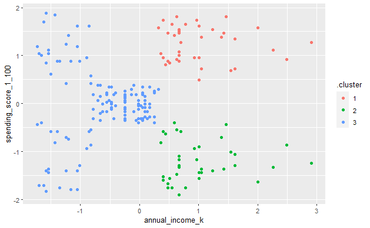

This second plot is interesting because adds three ‘points’ of the medium to the high annual income and lower spending_score.Also, the medium group of medium income and spending is add to the group of lower income and low or high spending_score. Leaving the ‘green’ cluster : high annual income and low spending_score like the targeting group.

| .cluster | mean(annual_income_k) | mean(spending_score_1_100) |
| --- | --- | --- |
| 1 | 0.9891010 | 1.23640011 |
| 2 | 1.0066735 | -1.22246770 |
| 3 | -0.6246222 | -0.01435636 |